# BUA 345 - Lecture 23 - Forecasting - Part 2

Penelope Pooler Eisenbies

2023-04-20

### Reminders and Upcoming Dates

- **Evaluations are VERY Important:**
  - **[coursefeedback.syr.edu](http://coursefeedback.syr.edu/)**
  - I will end class 5 min. early today and next Thursday to give you time to complete evaluations in class.
  - Please complete evaluations for **ALL** courses.
- **HW 10 is due Monday, 4/24**
- **Optional Lecture on 4/25**
  - Developing R Functions for Time Series Analysis
- **Course Review on 4/27 (Required)**

### Reminder of Using R and R Markdown Files

- Download Zipped R project
- Open Zipped folder and copy internal folder (R Project) to a BUA 345 folder on your computer NOT IN DOWLOADS
- **Open R Project:**
  - *OPTION 1:* Click on .Rproj file to open project and RStudio
  - *OPTION 2:* Open RStudio, then click File > Open Project > then navigate to and click on .Rproj file.
- **Once Project is opened in RStudio:**
  - Click on `code_data_output` file to open it.
  - Click on `BUA_345_Lecture_23.Rmd` to open it.
  - Run `setup` Chunk

### Setup

- The setup chunk shows the packages needed for this demo.
- R will install specified packages if needed (only required once after R is installed)
- R will load specified packaged (required every time you start a new R session)
- The first time you run this code, R will install these packages which will be slow.
- **If you get warnings, that’s okay.**
- If you get **error messages**, I (or TA), can help you.

### Setup Chunk for Lecture 23

```r
# this line specifies options for default options for all R Chunks
knitr::opts_chunk$set(echo=T, highlight=T)
# suppress scientific notation
options(scipen=100)

# install helper package that loads and installs other packages, if needed
if (!require("pacman")) install.packages("pacman", repos = "http://lib.stat.cmu.edu/R/CRAN/")
```

```r
# install and load required packages
pacman::p_load(pacman,tidyverse, magrittr, knitr, gridExtra, forecast, tidyquant, lubridate, maps, usdata, mapproj, ggthemes, RColorBrewer, dygraphs, climate)
# verify packages - it's a long list
p_loaded()
```

```
##  [1] "dygraphs"             "RColorBrewer"         "ggthemes"
##  [4] "mapproj"              "usdata"               "maps"
##  [7] "tidyquant"            "quantmod"             "TTR"
## [10] "PerformanceAnalytics" "xts"                  "zoo"
## [13] "forecast"             "gridExtra"            "knitr"
## [16] "magrittr"             "lubridate"            "forcats"
## [19] "stringr"              "dplyr"                "purrr"
## [22] "readr"                "tidyr"                "tibble"
## [25] "ggplot2"              "tidyverse"            "pacman"
```

**NOTES:**

- Please make sure you can open the provided R project for the practice questions and run the setup chunk without errors.
- If you are having trouble installing/loading any packages, please come to office hour or make an appointment with me or course TA.

### Plan for Today

- **Review of Time Series Concepts**
  - **Redemption for Syracuse!**
  - Review and New Terminology
- Review of Time Series without Seasonality
- Seasonality in Time Series Data
- Forecasting Trends with Seasonality in R
  - Example from HW 10: Alaska
  - Data in HW 10 end in Q4 of 2021
  - Data in Lecture 23 end in Q4 of 2022

#### HW Assignment 10

- **Today:** Questions 7 - 10

#### Cross-Sectional Data

- Shows a Snapshot of One Time Period

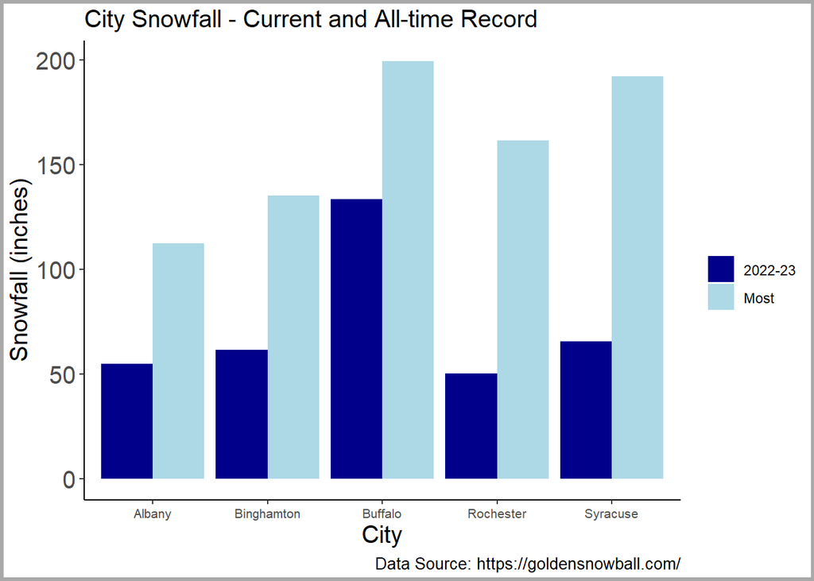

```r
gsb23 <- read_csv("gsb_23.csv", show_col_types = F, skip=25,
                  col_select = c(1,2,6), ) |>
  slice(1:5) |>
  rename("city" = "...1",
         "2022-23" = "...2",
         "Most" = "...6") |>

  mutate(Most = substr(Most, 1,5) |> as.numeric())

gsb_long <- gsb23 |> pivot_longer(cols = `2022-23`:Most,
                               names_to = "type",
                               values_to = "inches")
(gsb_plt <- gsb_long |>
  ggplot() +
  geom_bar(aes(x=city, y=inches, fill=type),
                stat="identity", position="dodge") +
  scale_fill_manual(values=c("blue4", "lightblue")) +
  theme_classic() +
  labs(fill="", x="City", y="Snowfall (inches)",
       caption="Data Source: https://goldensnowball.com/",
       title="City Snowfall - Current and All-time Record")+
  theme(plot.title = element_text(size = 15),
        plot.caption = element_text(size = 10),
        axis.title.x = element_text(size = 15),
        axis.title.y = element_text(size = 15),
        axis.text.x = element_text(size = 8),
        axis.text.y = element_text(size = 15),
         plot.background =
          element_rect(colour = "darkgrey", fill=NA, linewidth=2)))
```

#### Time Series Data

- Shows Trend over Time

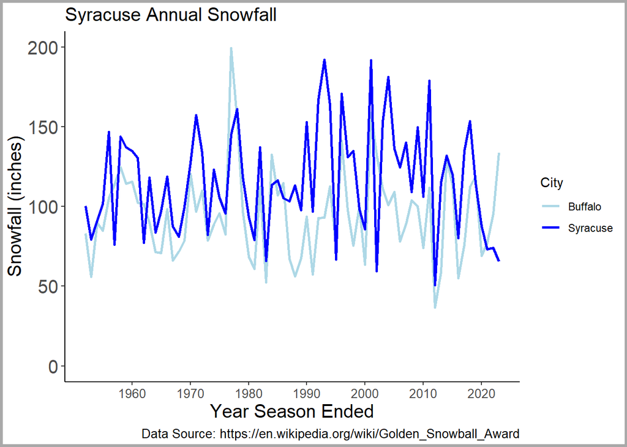

```r
snowfall <- read_csv("snowfall_upstateny_cities.csv",
                     show_col_types = F) |>
  filter(!Season=="Season") |>
  separate(Season, into=c("Season_Start", "Season_End"), sep = "-") |>
  mutate(Season_Start = Season_Start |> as.integer(),
         Season_End = Season_Start + 1 |> as.integer(),
         Syracuse = Syracuse |> as.numeric(),
         Buffalo = Buffalo |> as.numeric()) |>
  rename("city_most" = "City With Most Snow") |>
  select(Season_End, Syracuse, Buffalo, city_most) |>
  filter(Season_End >= 1952) |>
  pivot_longer(cols=Syracuse:Buffalo, names_to = "City", values_to = "Snowfall")

(line_plot <- snowfall |>
  ggplot() +
  geom_line(aes(x=Season_End, y=Snowfall, color=City), linewidth=1) +
  theme_classic() +
  scale_x_continuous(breaks=seq(1960, 2020, 10)) +
  scale_color_manual(values=c("lightblue", "blue")) +
  ylim(0,200) +

  labs(title="Syracuse Annual Snowfall",
       y="Snowfall (inches)",
       x="Year Season Ended",
       caption="Data Source: https://en.wikipedia.org/wiki/Golden_Snowball_Award") +
  theme(plot.title = element_text(size = 15),
        plot.caption = element_text(size = 10),
        axis.title.x = element_text(size = 15),
        axis.title.y = element_text(size = 15),
        axis.text.x = element_text(size = 10),
        axis.text.y = element_text(size = 15),
         plot.background =
          element_rect(colour = "darkgrey", fill=NA, linewidth=2)))
```

### Time Series Terminology

–

- **auto-correlation:** A variable is correlated with itself
- **auto-regression (AR):** Using previous observations to predict into the future.
- **R function:** **`auto.arima` - ARIMA** is an acronym:
  - **AR:** auto-regressive - `p` = number of lags to minimize auto-correlation
  - **I:** integrated - `d` = order of differencing to achieve stationarity
  - **MA:** moving average - `q` = number of terms in moving average
  - All 3 components are optimized to provide a reliable forecast.

### More on Stationarity

- **Stationary Time Series:**
  - Consistent mean and variance throughout time series
  - Time series with trends, or with seasonality, are not stationary.
  - Separating a time series into different parts is how we analyze it
    - This is called **DECOMPOSITION**
    - Time Series Modeling decomposes the data into:
      - Trend
      - Seasonality (repeated pattern)
      - Residuals (what’s left over)

### Decomposition and SARIMA Models

#### **NEW TERM: SARIMA model**

- Lecture 22: **ARIMA** models
- Today: ARIMA models with **SEASONAL** component.
- **SARIMA:** **S**easonal **A**uto-**R**egressive **I**ntegrated **M**oving **A**verage.

–

- **SARIMA** models:
  - optimize `p`, `d`, and `q` for whole time series
  - Also optimize `p`, `d`, and `q` within season (repeating intervals)

–

#### **Decomposition**

- ARIMA models are decomposed into
  - Trend | Residuals
- SARIMA models are decomposed into
  - Trend | Seasonal patterns | Residuals

*NOTE: NETFLIX REVIEW MATERIAL NOT INCLUDED IN LECTURE 23 NOTES*

- See Lecture 22 notes.

### Seasonality - Not Just Seasons

- Seasonal periods can be days, months, seasons, decades, etc.
- Seasonality: repeating pattern of highs and lows of approx. equal timespans

#### **Example: Temperature data has a daily seasonal pattern:**

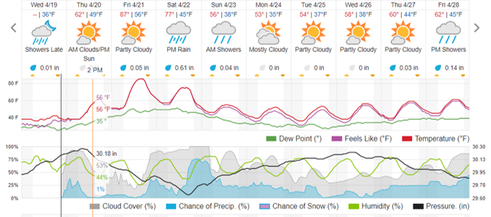

### Seasonality - Not Just Seasons

- Seasonal periods can be days, months, seasons, decades, etc.
- Seasonality: repeating pattern of highs and lows of approx. equal timespans

#### Carbon Dioxide Trends - Monthly - 1958 to Present Day

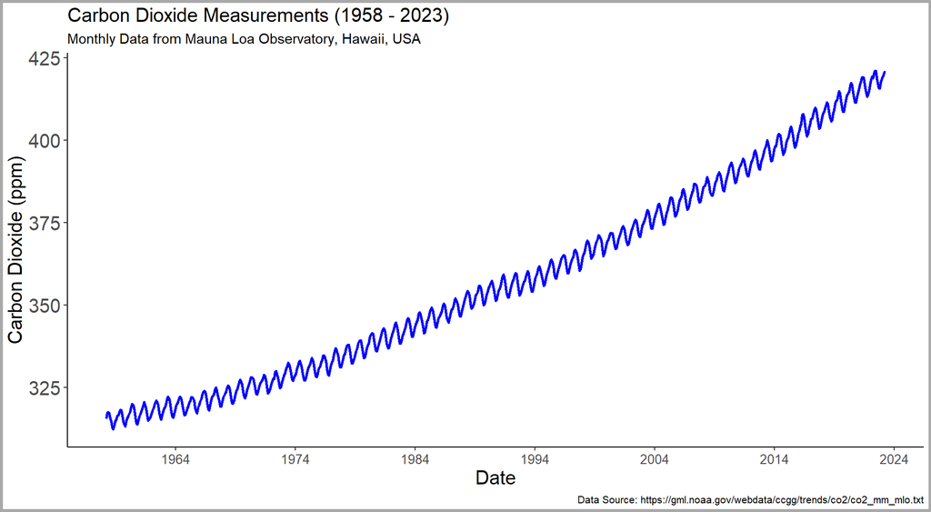

```r
(co2_plot <- co2 |>
  ggplot() +
  geom_line(aes(x=date, y=mnth_avg), color="blue", linewidth=1) +
  theme_classic() +
  labs(title="Carbon Dioxide Measurements (1958 - 2023)",
       subtitle="Monthly Data from Mauna Loa Observatory, Hawaii, USA",
       y="Carbon Dioxide (ppm)",
       x="Date",
       caption="Data Source: https://gml.noaa.gov/webdata/ccgg/trends/co2/co2_mm_mlo.txt") +
  scale_x_date(breaks = "10 years", date_labels = "%Y") +
  theme(plot.title = element_text(size = 15),
        plot.caption = element_text(size = 8),
        axis.title.x = element_text(size = 15),
        axis.title.y = element_text(size = 15),
        axis.text.x = element_text(size = 10),
        axis.text.y = element_text(size = 15),
        plot.background = element_rect(colour = "darkgrey", fill=NA, linewidth=2)))
```

### Seasonality - Not Just Seasons

- Seasonal periods can be days, months, seasons, decades, etc.
- Seasonality: repeating pattern of highs and lows of approx. equal timespans

#### Carbon Dioxide - Monthly - 2014 to Present Day

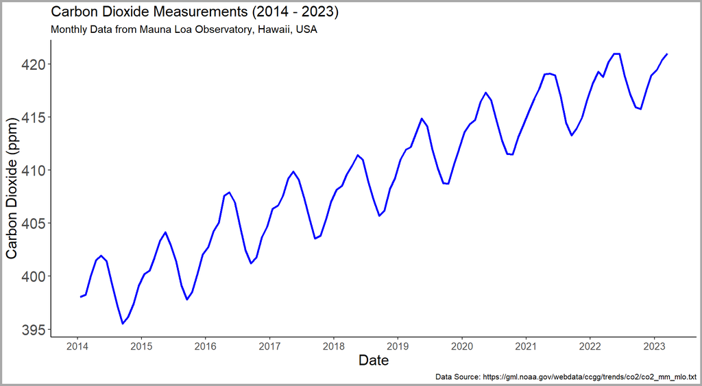

```r
co2_1 <- co2 |> filter(yr >= 2014)

(co2_plot1 <- co2_1|>
  ggplot() +
  geom_line(aes(x=date, y=mnth_avg), color="blue", linewidth=1) +
  theme_classic() +
  labs(title="Carbon Dioxide Measurements (2014 - 2023)",
       subtitle="Monthly Data from Mauna Loa Observatory, Hawaii, USA",
       y="Carbon Dioxide (ppm)",
       x="Date",
       caption="Data Source: https://gml.noaa.gov/webdata/ccgg/trends/co2/co2_mm_mlo.txt") +
  scale_x_date(breaks = "1 year", date_labels = "%Y") +
  theme(plot.title = element_text(size = 15),
        plot.caption = element_text(size = 8),
        axis.title.x = element_text(size = 15),
        axis.title.y = element_text(size = 15),
        axis.text.x = element_text(size = 10),
        axis.text.y = element_text(size = 15),
        plot.background = element_rect(colour = "darkgrey", fill=NA, linewidth=2)))
```

### Seasonal Data: Alaska Electricity Revenue

**Alaska is very far north** so there is

- *summer light* (day and night)
- *winter darkness* (day and night)

Alaska Electricity usage has a **strong** seasonal pattern.

**Data range for Lecture 23** - Start: First quarter of 2001 - End: Last quarter of 2022 (HW 10 data end in 2021)

In addition to seasonality, we expect an upward trend in revenue due to: - Increase in population - Inflation of electricity prices

**Notes: Lecture 23 data were updated through 2022 but HW 10 Alaska data end in 2021**

```r
# a little data mgmt (if you are interested)
ak_res <- read_csv("AK_Residential_Electricity_Revenue_Updated.csv",
                   show_col_types = F,
                   skip=5,
                   col_names = c("quarter","Revenue")) |>
  separate(quarter, c("Quarter", "Year")) |>
  mutate(Date=yq(paste(Year, Quarter))) |>
  select(Date, Revenue) |>
  arrange(Date) |>
  glimpse(width=50)
```

```
## Rows: 88
## Columns: 2
## $ Date    <date> 2001-01-01, 2001-04-01, 2001-07…
## $ Revenue <dbl> 62.82329, 51.47989, 49.17193, 65…
```

–

#### **Alaska Residential Electricity Time Series**

```r
# convert to xts (extensible time series)
ak_res_xts <- xts(x = ak_res[,2], order.by = ak_res$Date)

# ak-res interactive time_series
(ak_dg <- dygraph(ak_res_xts, main="Alaska Residential Electricity Revenue ($Mill)") |>
    dySeries("Revenue", label="Revenue", color= "purple") |>
    dyAxis("y", label = "", drawGrid = FALSE) |>
    dyAxis("x", label = "", drawGrid = FALSE) |>
    dyRangeSelector())
```

[interactive chart not shown]

### **Alaska Residential Time Series**

- Create Time Series and Examine it:

```r
# create time series using ts command
ak_res_ts <- ts(ak_res$Revenue, freq=4, start=c(2001, 1))
```

- Format of Time Series with Quarters:
  - Specifying time series this way formats data as a matrix.
  - `head(ak_res_ts, 20)` shows first 20 observations and format.

```r
head(ak_res_ts, 20)
```

```
##          Qtr1     Qtr2     Qtr3     Qtr4
## 2001 62.82329 51.47989 49.17193 65.69389
## 2002 67.15059 54.59481 50.45345 60.57016
## 2003 66.05993 52.41459 51.81904 67.77145
## 2004 72.43865 58.10685 54.88616 71.02934
## 2005 76.49769 59.89544 59.25575 78.50312
```

### **Alaska Residential Electricity Time Series**

#### **Incorrect Model: Ignores Seasonality (`seasonal = F`)**

- Notice how wide prediction intervals are.
- Model only optimizes `p`, `d`, and `q` for full time series `(0,1,0)`.

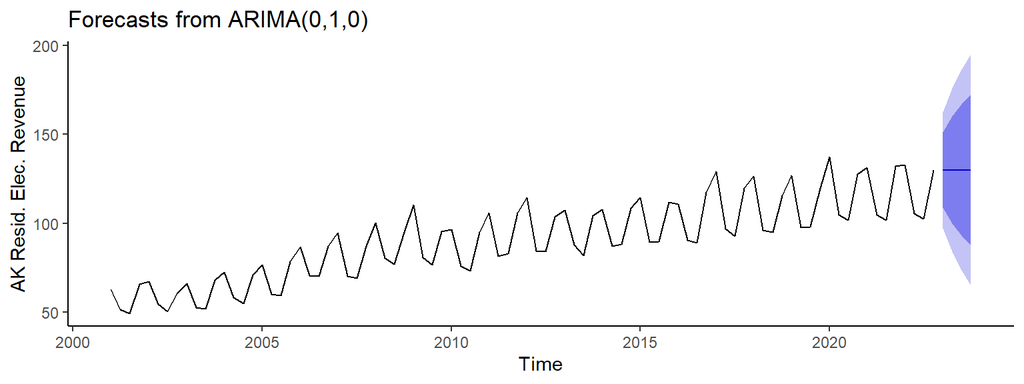

```r
ak_res_forecast1 <- ak_res_ts |>
  auto.arima(ic="aic", seasonal=F) |>
  forecast(h=4)
(autoplot(ak_res_forecast1) + labs(y = "AK Resid. Elec. Revenue") + theme_classic())
```

### **Alaska Residential Electricity Time Series**

#### **Correct Model: Includes Seasonality (`seasonal = T`)**

- Prediction intervals are **MUCH** more narrow
- Optimizes `p`, `d` and `q` for full time series `(1,0,0)` and within season `(0,1,1)`.
- Indicates number of time periods within season, `[4]`

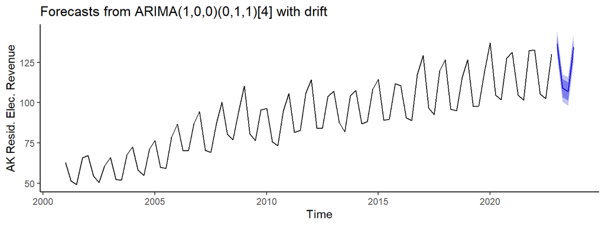

```r
ak_res_forecast2 <- ak_res_ts |>
  auto.arima(ic="aic", seasonal=T) |>
  forecast(h=4)
(autoplot(ak_res_forecast2) + labs(y = "AK Resid. Elec. Revenue") + theme_classic())
```

### Model Comparison

#### **Incorrect Model: LESS PRECISE**

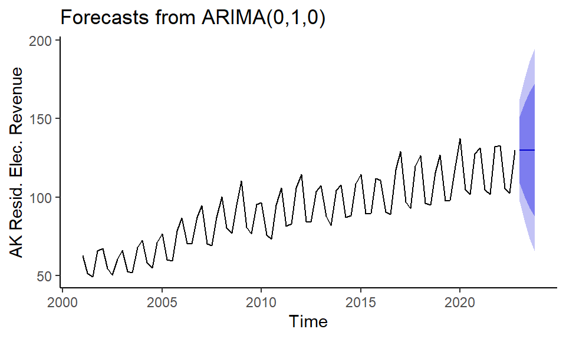

| Year | Qtr | Pt | Lo95 | Hi95 |
| --- | --- | --- | --- | --- |
| 2023 | 1 | 129.94 | 97.37 | 162.51 |
| 2023 | 2 | 129.94 | 83.88 | 175.99 |
| 2023 | 3 | 129.94 | 73.53 | 186.35 |
| 2023 | 4 | 129.94 | 64.81 | 195.07 |

```r
(autoplot(ak_res_forecast1) + labs(y = "AK Resid. Elec. Revenue") + theme_classic())
```

**`Q4 Width = Hi - Lo = $130`**

#### **Correct Model: MORE PRECISE**

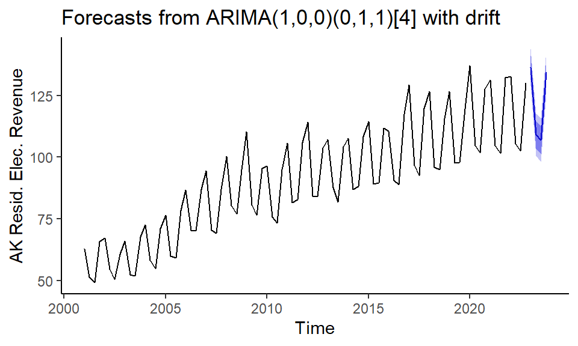

| Year | Qtr | Pt | Lo95 | Hi95 |
| --- | --- | --- | --- | --- |
| 2023 | 1 | 136.46 | 129.02 | 143.90 |
| 2023 | 2 | 109.12 | 100.57 | 117.66 |
| 2023 | 3 | 107.00 | 98.13 | 115.88 |
| 2023 | 4 | 134.48 | 125.50 | 143.45 |

```r
(autoplot(ak_res_forecast2) + labs(y = "AK Resid. Elec. Revenue") + theme_classic())
```

**`Q4 Width = Hi - Lo = $18`**

### Prediction Bands Indicate Model Precision

- Prediction bands are MUCH narrower when seasonality is accounted for.

#### Incorrect Model Forecasts and Prediction Bounds

```r
ak_res_forecast1
```

```
##         Point Forecast     Lo 80    Hi 80    Lo 95    Hi 95
## 2023 Q1        129.939 108.64501 151.2330 97.37265 162.5054
## 2023 Q2        129.939  99.82475 160.0533 83.88323 175.9948
## 2023 Q3        129.939  93.05672 166.8213 73.53243 186.3456
## 2023 Q4        129.939  87.35102 172.5270 64.80630 195.0717
```

#### Correct Model Forecasts and Prediction Bounds

```r
ak_res_forecast2
```

```
##         Point Forecast    Lo 80    Hi 80     Lo 95    Hi 95
## 2023 Q1       136.4598 131.5962 141.3235 129.02151 143.8982
## 2023 Q2       109.1161 103.5276 114.7046 100.56927 117.6629
## 2023 Q3       107.0039 101.2024 112.8054  98.13131 115.8766
## 2023 Q4       134.4788 128.6107 140.3469 125.50435 143.4533
```

- **Interpretation of 95% Prediction Bounds:**
- We are 95% certain that 4th qtr. revenue in 2023 will fall within:
  - Incorrect model range: **`$195.07 - $64.81 = $130`**
  - Correct model range: **`$143.45 - $125.50 = $18`**

#### Comparison of Model Residuals

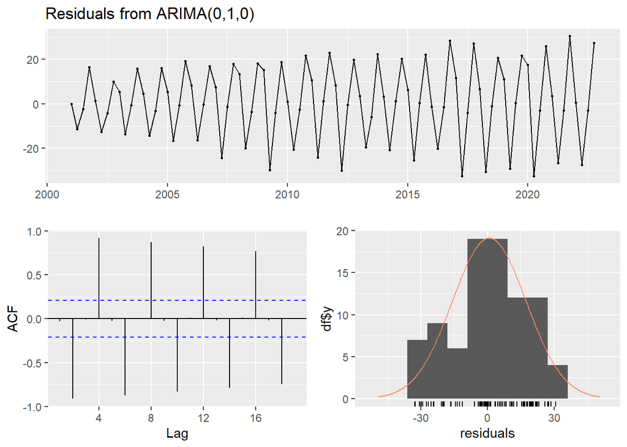

```r
checkresiduals(ak_res_forecast1, test=F)
```

**Incorrect Model:**  
- Residuals **MUCH** larger - Are highly correlated - See ACF plot - Residual plots indicate model is **INCORRECTLY** specified and invalid.

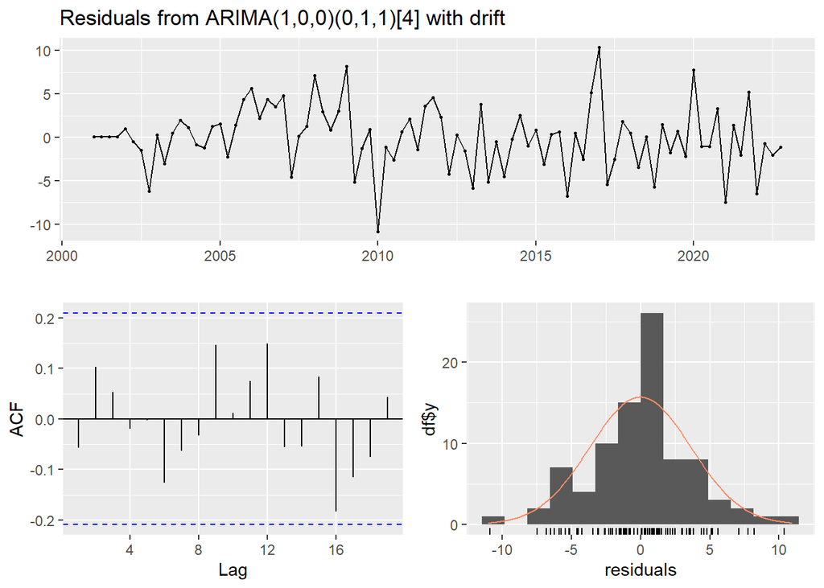

```r
checkresiduals(ak_res_forecast2, test=F)
```

**Correct Model:**  
- Residuals **MUCH** smaller - Auto-correlation assumption is met - ACF plot: lags in range - Residual plots indicate model is **CORRECTLY** specified and valid.

### Comparison of Model Accuracy

```r
(acr1 <- accuracy(ak_res_forecast1))
```

```
##                     ME     RMSE      MAE        MPE    MAPE     MASE       ACF1
## Training set 0.7633924 16.52111 13.11085 -0.7495366 14.4931 2.960528 -0.0287675
```

- **The incorrect model’s percent accuracy is 85.5%.**
- Better than expected.

```r
(acr2 <- accuracy(ak_res_forecast2))
```

```
##                       ME     RMSE     MAE        MPE     MAPE      MASE
## Training set -0.02682329 3.641066 2.72117 -0.1430706 2.924482 0.6144606
##                     ACF1
## Training set -0.05698521
```

- **The correct model’s percent accuracy is 97.1%.**
- Always plot data, but if seasonality is difficult to discern, run both models and compare them.
- Residuals and model accuracy of models will indicate which model is correct.

### Key Points from Today

- **R `forecast` package** - simplifies forecasting**
- **Know terminology and how to read and interpret output.**
- **Plot data FIRST:** - Check for seasonality, trend, other patterns
- **HW 10 covers Lectures 21-23 (Due Mon. 4/24)**
- **Lecture 24 (Tue. 4/25) - Optional**
  - Developing Time Series Functions in R
- **Lecture 25 - Required Review:**
  - 20 min. of lecture with Point Solutions, then Q&A - Come with questions!
- **Evaluations are VERY Important:**
  - **[coursefeedback.syr.edu](http://coursefeedback.syr.edu/)**

You may submit an ‘Engagement Question’ about each lecture until midnight on the day of the lecture. **A minimum of four submissions are required during the semester.**